# SWE 402 Assignment : Python for Data Analysis

## Team Members:

1. Khor Jia Cheng SWE1809651 (Leader)
2. Leong Wei Jun SWE1809654

## Dataset Used for the Analysis

###### The dataset used for this assignmnent is from Kaggle. Link of the website : https://www.kaggle.com/jesendo/malaysia-covid19

### Exploratory Data Analysis

Before we start for the data analysis,the dataset must be prepared and cleaned. First and foremost, excecute the code in the cell below to load the packages to run the rest of this notebook.

```python
import pandas as pd
import numpy as np
import seaborn as sns                       #visualisation
import matplotlib.pyplot as plt             #visualisation
import numpy.random as nr
import math
%matplotlib inline

sns.set(color_codes=True)
```

The code in the cell below loads the datasets into their respectives dataframe, read the first five records, and check the length of the data.The datasets involves COVID-199 death cases, COVID-19 cases, type of test for COVID-19, and type of vaccination.

```python
df_case = pd.read_csv("cases_malaysia.csv")
df_death = pd.read_csv("deaths_malaysia.csv")
df_test = pd.read_csv("tests_malaysia.csv")
df_vax = pd.read_csv("vax_malaysia.csv")
```

```python
df_case.head(5)
```

|  | date | cases_new | cases_import | cases_recovered | cases_active | cases_cluster | cases_unvax | cases_pvax | cases_fvax | cases_boost | cases_child | cases_adolescent | cases_adult | cases_elderly | cases_0_4 | cases_5_11 | cases_12_17 | cases_18_29 | cases_30_39 | cases_40_49 | cases_50_59 | cases_60_69 | cases_70_79 | cases_80 | cluster_import | cluster_religious | cluster_community | cluster_highRisk | cluster_education | … |
| --- | --- | --- | --- | --- | --- | --- | --- | --- | --- | --- | --- | --- | --- | --- | --- | --- | --- | --- | --- | --- | --- | --- | --- | --- | --- | --- | --- | --- | --- | --- |
| 0 | 2020-01-25 | 4 | 4 | 0 | 4 | 0.0 | 4.0 | 0.0 | 0.0 | 0.0 | 0.0 | 0.0 | 1.0 | 0.0 | 0.0 | 0.0 | 0.0 | 0.0 | 0.0 | 1.0 | 0.0 | 0.0 | 0.0 | 0.0 | NaN | NaN | NaN | NaN | NaN | … |
| 1 | 2020-01-26 | 0 | 0 | 0 | 4 | 0.0 | 0.0 | 0.0 | 0.0 | 0.0 | 0.0 | 0.0 | 0.0 | 0.0 | 0.0 | 0.0 | 0.0 | 0.0 | 0.0 | 0.0 | 0.0 | 0.0 | 0.0 | 0.0 | NaN | NaN | NaN | NaN | NaN | … |
| 2 | 2020-01-27 | 0 | 0 | 0 | 4 | 0.0 | 0.0 | 0.0 | 0.0 | 0.0 | 0.0 | 0.0 | 0.0 | 0.0 | 0.0 | 0.0 | 0.0 | 0.0 | 0.0 | 0.0 | 0.0 | 0.0 | 0.0 | 0.0 | NaN | NaN | NaN | NaN | NaN | … |
| 3 | 2020-01-28 | 0 | 0 | 0 | 4 | 0.0 | 0.0 | 0.0 | 0.0 | 0.0 | 0.0 | 0.0 | 0.0 | 0.0 | 0.0 | 0.0 | 0.0 | 0.0 | 0.0 | 0.0 | 0.0 | 0.0 | 0.0 | 0.0 | NaN | NaN | NaN | NaN | NaN | … |
| 4 | 2020-01-29 | 3 | 3 | 0 | 7 | 0.0 | 3.0 | 0.0 | 0.0 | 0.0 | 1.0 | 0.0 | 2.0 | 0.0 | 1.0 | 0.0 | 0.0 | 0.0 | 1.0 | 0.0 | 1.0 | 0.0 | 0.0 | 0.0 | NaN | NaN | NaN | NaN | NaN | … |

```python
df_test.head(5)
```

|  | date | rtk-ag | pcr |
| --- | --- | --- | --- |
| 0 | 2020-01-24 | 0 | 2 |
| 1 | 2020-01-25 | 0 | 5 |
| 2 | 2020-01-26 | 0 | 14 |
| 3 | 2020-01-27 | 0 | 24 |
| 4 | 2020-01-28 | 0 | 53 |

```python
df_death = df_death.drop(['deaths_bid','deaths_new_dod', 'deaths_bid_dod','deaths_unvax','deaths_pvax','deaths_fvax','deaths_boost','deaths_tat'], axis=1)
df_death.head(5)
```

|  | date | deaths_new |
| --- | --- | --- |
| 0 | 2020-03-17 | 2 |
| 1 | 2020-03-18 | 0 |
| 2 | 2020-03-19 | 0 |
| 3 | 2020-03-20 | 1 |
| 4 | 2020-03-21 | 4 |

```python
df_death.head(5)
```

|  | date | deaths_new |
| --- | --- | --- |
| 0 | 2020-03-17 | 2 |
| 1 | 2020-03-18 | 0 |
| 2 | 2020-03-19 | 0 |
| 3 | 2020-03-20 | 1 |
| 4 | 2020-03-21 | 4 |

```python
len(df_death)
```

```
646
```

**Removed Unused Data**

The cell below drops the column of covid cases dataset and vaccination dataset that may not used for the analysis.

```python
df_case = df_case.drop(['cases_cluster', 'cases_child','cases_adolescent','cases_adult','cases_elderly','cases_0_4','cases_5_11','cases_12_17','cases_18_29','cases_30_39','cases_40_49','cases_50_59','cases_60_69','cases_70_79','cases_80','cluster_import','cluster_religious','cluster_community','cluster_highRisk','cluster_education','cluster_detentionCentre','cluster_workplace' ], axis=1)
df_case.head(5)
```

|  | date | cases_new | cases_import | cases_recovered | cases_active | cases_unvax | cases_pvax | cases_fvax | cases_boost |
| --- | --- | --- | --- | --- | --- | --- | --- | --- | --- |
| 0 | 2020-01-25 | 4 | 4 | 0 | 4 | 4.0 | 0.0 | 0.0 | 0.0 |
| 1 | 2020-01-26 | 0 | 0 | 0 | 4 | 0.0 | 0.0 | 0.0 | 0.0 |
| 2 | 2020-01-27 | 0 | 0 | 0 | 4 | 0.0 | 0.0 | 0.0 | 0.0 |
| 3 | 2020-01-28 | 0 | 0 | 0 | 4 | 0.0 | 0.0 | 0.0 | 0.0 |
| 4 | 2020-01-29 | 3 | 3 | 0 | 7 | 3.0 | 0.0 | 0.0 | 0.0 |

```python
df_vax = df_vax.drop(['daily_partial','daily_full','daily_partial_child', 'daily_partial_child','daily_partial_child','daily_full_child','daily_booster','cumul_partial','cumul_full','cumul','cumul_partial_child','cumul_full_child','cumul_booster'], axis=1)
df_vax.head(5)
```

|  | date | daily | pfizer1 | pfizer2 | pfizer3 | sinovac1 | sinovac2 | sinovac3 | astra1 | astra2 | astra3 | sinopharm1 | sinopharm2 | sinopharm3 | cansino | cansino3 | pending1 | pending2 | pending3 |
| --- | --- | --- | --- | --- | --- | --- | --- | --- | --- | --- | --- | --- | --- | --- | --- | --- | --- | --- | --- |
| 0 | 2021-02-24 | 65 | 61 | 1 | 0 | 0 | 2 | 0 | 0 | 0 | 0 | 0 | 0 | 0 | 0 | 0 | 1 | 0 | 0 |
| 1 | 2021-02-25 | 1151 | 1147 | 0 | 0 | 0 | 2 | 0 | 0 | 0 | 0 | 0 | 0 | 0 | 0 | 0 | 2 | 0 | 0 |
| 2 | 2021-02-26 | 4068 | 4057 | 1 | 0 | 0 | 2 | 0 | 1 | 0 | 0 | 0 | 0 | 0 | 0 | 0 | 7 | 0 | 0 |
| 3 | 2021-02-27 | 6716 | 6692 | 1 | 0 | 0 | 5 | 0 | 0 | 0 | 0 | 0 | 0 | 0 | 0 | 0 | 18 | 0 | 0 |
| 4 | 2021-02-28 | 6717 | 6708 | 1 | 0 | 0 | 4 | 0 | 0 | 0 | 0 | 0 | 0 | 0 | 0 | 0 | 4 | 0 | 0 |

**Data Grouping**

The cell below groups the total of different types of vaccine dose taken daily by combining multiple columns.

```python
df_vax['pfizer'] =  df_vax['pfizer1']+ df_vax['pfizer2']+ df_vax['pfizer3']
df_vax['sinovac'] =  df_vax['sinovac1']+ df_vax['sinovac2']+ df_vax['sinovac3']
df_vax['astra'] =  df_vax['astra1']+ df_vax['astra2']+ df_vax['astra3']
df_vax['sinopharm'] =  df_vax['sinopharm1']+ df_vax['sinopharm2']+ df_vax['sinopharm3']
df_vax['tot_cansino'] =  df_vax['cansino']+ df_vax['cansino3']
df_vax['pending'] =  df_vax['pending1']+ df_vax['pending2']+ df_vax['pending3']

df_vax = df_vax.drop(['pfizer1','pfizer2','pfizer3', 'sinovac1','sinovac2','sinovac3','astra1','astra2','astra3','sinopharm1','sinopharm2','sinopharm3','cansino','cansino3','pending1','pending2','pending3'], axis=1)
df_vax
```

|  | date | daily | pfizer | sinovac | astra | sinopharm | tot_cansino | pending |
| --- | --- | --- | --- | --- | --- | --- | --- | --- |
| 0 | 2021-02-24 | 65 | 62 | 2 | 0 | 0 | 0 | 1 |
| 1 | 2021-02-25 | 1151 | 1147 | 2 | 0 | 0 | 0 | 2 |
| 2 | 2021-02-26 | 4068 | 4058 | 2 | 1 | 0 | 0 | 7 |
| 3 | 2021-02-27 | 6716 | 6693 | 5 | 0 | 0 | 0 | 18 |
| 4 | 2021-02-28 | 6717 | 6709 | 4 | 0 | 0 | 0 | 4 |
| ... | ... | ... | ... | ... | ... | ... | ... | ... |
| 297 | 2021-12-18 | 72164 | 3672 | 1906 | 108 | 128 | 134 | 66216 |
| 298 | 2021-12-19 | 79498 | 56218 | 10148 | 2095 | 84 | 209 | 10744 |
| 299 | 2021-12-20 | 146136 | 121474 | 21211 | 1689 | 249 | 119 | 1394 |
| 300 | 2021-12-21 | 168138 | 144477 | 19502 | 2104 | 206 | 110 | 1739 |
| 301 | 2021-12-22 | 177272 | 146761 | 19917 | 3010 | 219 | 187 | 7178 |

302 rows × 8 columns

**Recode Name**

Notice that one of the column names in df_test contain the '-' character. Python will not correctly recognize character strings containing '-'. Rather, such a name will be recognized as two character strings. The same problem will occur with column values containing many special characters including, '-', ',', '*', '/', '|', '>', '<', '@', '!' etc. If such characters appear in column names of values, they must be replaced with another character.

Execute the code in the cell below to replace the '-' characters by '_' :

```python
df_test.columns = [str.replace('-', '_') for str in df_test.columns]
print(df_test.columns)
```

```
Index(['date', 'rtk_ag', 'pcr'], dtype='object')
```

Combining Multiple Dataframe to One Dataframe After removing the unused data, we may combining all of the dataframes to one dataframe called **df** using inner join with the use of **date** attribute.

```python
df_vax_test = pd.merge(df_vax, df_test, on='date', how='inner')
df_vax_test
```

|  | date | daily | pfizer | sinovac | astra | sinopharm | tot_cansino | pending | rtk_ag | pcr |
| --- | --- | --- | --- | --- | --- | --- | --- | --- | --- | --- |
| 0 | 2021-02-24 | 65 | 62 | 2 | 0 | 0 | 0 | 1 | 44841 | 30281 |
| 1 | 2021-02-25 | 1151 | 1147 | 2 | 0 | 0 | 0 | 2 | 47439 | 38490 |
| 2 | 2021-02-26 | 4068 | 4058 | 2 | 1 | 0 | 0 | 7 | 46207 | 34014 |
| 3 | 2021-02-27 | 6716 | 6693 | 5 | 0 | 0 | 0 | 18 | 34017 | 29550 |
| 4 | 2021-02-28 | 6717 | 6709 | 4 | 0 | 0 | 0 | 4 | 32557 | 26969 |
| ... | ... | ... | ... | ... | ... | ... | ... | ... | ... | ... |
| 295 | 2021-12-16 | 174433 | 18946 | 3813 | 325 | 268 | 150 | 150931 | 91581 | 33616 |
| 296 | 2021-12-17 | 162223 | 9730 | 2690 | 144 | 253 | 138 | 149268 | 78413 | 31077 |
| 297 | 2021-12-18 | 72164 | 3672 | 1906 | 108 | 128 | 134 | 66216 | 62603 | 30918 |
| 298 | 2021-12-19 | 79498 | 56218 | 10148 | 2095 | 84 | 209 | 10744 | 67749 | 24185 |
| 299 | 2021-12-20 | 146136 | 121474 | 21211 | 1689 | 249 | 119 | 1394 | 114220 | 31012 |

300 rows × 10 columns

```python
df_death_case= pd.merge(df_death, df_case, on='date', how='inner')
df_death_case
```

|  | date | deaths_new | cases_new | cases_import | cases_recovered | cases_active | cases_unvax | cases_pvax | cases_fvax | cases_boost |
| --- | --- | --- | --- | --- | --- | --- | --- | --- | --- | --- |
| 0 | 2020-03-17 | 2 | 120 | 3 | 7 | 622 | 120.0 | 0.0 | 0.0 | 0.0 |
| 1 | 2020-03-18 | 0 | 117 | 8 | 11 | 728 | 117.0 | 0.0 | 0.0 | 0.0 |
| 2 | 2020-03-19 | 0 | 110 | 5 | 15 | 823 | 110.0 | 0.0 | 0.0 | 0.0 |
| 3 | 2020-03-20 | 1 | 130 | 6 | 12 | 940 | 130.0 | 0.0 | 0.0 | 0.0 |
| 4 | 2020-03-21 | 4 | 153 | 11 | 27 | 1062 | 153.0 | 0.0 | 0.0 | 0.0 |
| ... | ... | ... | ... | ... | ... | ... | ... | ... | ... | ... |
| 641 | 2021-12-18 | 29 | 4083 | 34 | 5435 | 54000 | 1024.0 | 22.0 | 2893.0 | 144.0 |
| 642 | 2021-12-19 | 19 | 3108 | 37 | 3701 | 53389 | 692.0 | 22.0 | 2251.0 | 143.0 |
| 643 | 2021-12-20 | 43 | 2589 | 46 | 3810 | 52161 | 653.0 | 21.0 | 1819.0 | 96.0 |
| 644 | 2021-12-21 | 57 | 3140 | 58 | 4278 | 51023 | 746.0 | 23.0 | 2211.0 | 160.0 |
| 645 | 2021-12-22 | 29 | 3519 | 100 | 5118 | 49395 | NaN | NaN | NaN | NaN |

646 rows × 10 columns

```python
df =  pd.merge(df_death_case, df_vax_test, on='date', how='inner')
df
```

|  | date | deaths_new | cases_new | cases_import | cases_recovered | cases_active | cases_unvax | cases_pvax | cases_fvax | cases_boost | daily | pfizer | sinovac | astra | sinopharm | tot_cansino | pending | rtk_ag | pcr |
| --- | --- | --- | --- | --- | --- | --- | --- | --- | --- | --- | --- | --- | --- | --- | --- | --- | --- | --- | --- |
| 0 | 2021-02-24 | 12 | 3545 | 1 | 3331 | 30572 | 3545.0 | 0.0 | 0.0 | 0.0 | 65 | 62 | 2 | 0 | 0 | 0 | 1 | 44841 | 30281 |
| 1 | 2021-02-25 | 13 | 1924 | 6 | 3752 | 28738 | 1924.0 | 0.0 | 0.0 | 0.0 | 1151 | 1147 | 2 | 0 | 0 | 0 | 2 | 47439 | 38490 |
| 2 | 2021-02-26 | 10 | 2253 | 7 | 3085 | 27903 | 2253.0 | 0.0 | 0.0 | 0.0 | 4068 | 4058 | 2 | 1 | 0 | 0 | 7 | 46207 | 34014 |
| 3 | 2021-02-27 | 10 | 2364 | 1 | 3320 | 26937 | 2364.0 | 0.0 | 0.0 | 0.0 | 6716 | 6693 | 5 | 0 | 0 | 0 | 18 | 34017 | 29550 |
| 4 | 2021-02-28 | 9 | 2437 | 1 | 3251 | 26118 | 2437.0 | 0.0 | 0.0 | 0.0 | 6717 | 6709 | 4 | 0 | 0 | 0 | 4 | 32557 | 26969 |
| ... | ... | ... | ... | ... | ... | ... | ... | ... | ... | ... | ... | ... | ... | ... | ... | ... | ... | ... | ... |
| 295 | 2021-12-16 | 37 | 4262 | 36 | 4985 | 56156 | 955.0 | 29.0 | 3109.0 | 169.0 | 174433 | 18946 | 3813 | 325 | 268 | 150 | 150931 | 91581 | 33616 |
| 296 | 2021-12-17 | 18 | 4362 | 28 | 5098 | 55380 | 969.0 | 47.0 | 3168.0 | 178.0 | 162223 | 9730 | 2690 | 144 | 253 | 138 | 149268 | 78413 | 31077 |
| 297 | 2021-12-18 | 29 | 4083 | 34 | 5435 | 54000 | 1024.0 | 22.0 | 2893.0 | 144.0 | 72164 | 3672 | 1906 | 108 | 128 | 134 | 66216 | 62603 | 30918 |
| 298 | 2021-12-19 | 19 | 3108 | 37 | 3701 | 53389 | 692.0 | 22.0 | 2251.0 | 143.0 | 79498 | 56218 | 10148 | 2095 | 84 | 209 | 10744 | 67749 | 24185 |
| 299 | 2021-12-20 | 43 | 2589 | 46 | 3810 | 52161 | 653.0 | 21.0 | 1819.0 | 96.0 | 146136 | 121474 | 21211 | 1689 | 249 | 119 | 1394 | 114220 | 31012 |

300 rows × 19 columns

After all of the dataframe had been joined into **df**, we check on the length of the dataframe, which is 300 records.

```python
df.count()
```

```
date               300
deaths_new         300
cases_new          300
cases_import       300
cases_recovered    300
cases_active       300
cases_unvax        300
cases_pvax         300
cases_fvax         300
cases_boost        300
daily              300
pfizer             300
sinovac            300
astra              300
sinopharm          300
tot_cansino        300
pending            300
rtk_ag             300
pcr                300
dtype: int64
```

```python
df.tail(5)
```

|  | date | deaths_new | cases_new | cases_import | cases_recovered | cases_active | cases_unvax | cases_pvax | cases_fvax | cases_boost | daily | pfizer | sinovac | astra | sinopharm | tot_cansino | pending | rtk_ag | pcr |
| --- | --- | --- | --- | --- | --- | --- | --- | --- | --- | --- | --- | --- | --- | --- | --- | --- | --- | --- | --- |
| 295 | 2021-12-16 | 37 | 4262 | 36 | 4985 | 56156 | 955.0 | 29.0 | 3109.0 | 169.0 | 174433 | 18946 | 3813 | 325 | 268 | 150 | 150931 | 91581 | 33616 |
| 296 | 2021-12-17 | 18 | 4362 | 28 | 5098 | 55380 | 969.0 | 47.0 | 3168.0 | 178.0 | 162223 | 9730 | 2690 | 144 | 253 | 138 | 149268 | 78413 | 31077 |
| 297 | 2021-12-18 | 29 | 4083 | 34 | 5435 | 54000 | 1024.0 | 22.0 | 2893.0 | 144.0 | 72164 | 3672 | 1906 | 108 | 128 | 134 | 66216 | 62603 | 30918 |
| 298 | 2021-12-19 | 19 | 3108 | 37 | 3701 | 53389 | 692.0 | 22.0 | 2251.0 | 143.0 | 79498 | 56218 | 10148 | 2095 | 84 | 209 | 10744 | 67749 | 24185 |
| 299 | 2021-12-20 | 43 | 2589 | 46 | 3810 | 52161 | 653.0 | 21.0 | 1819.0 | 96.0 | 146136 | 121474 | 21211 | 1689 | 249 | 119 | 1394 | 114220 | 31012 |

**Check the types of data**

Here we check for the datatypes and found that cases_unvax, case_pvax, case_fvax, and case_boost are all stored as float. However, the date for three of these columns could be treated as int as the cases were all in whole number.

```python
df.dtypes
```

```
date                object
deaths_new           int64
cases_new            int64
cases_import         int64
cases_recovered      int64
cases_active         int64
cases_unvax        float64
cases_pvax         float64
cases_fvax         float64
cases_boost        float64
daily                int64
pfizer               int64
sinovac              int64
astra                int64
sinopharm            int64
tot_cansino          int64
pending              int64
rtk_ag               int64
pcr                  int64
dtype: object
```

```python
df['cases_unvax'] = df['cases_unvax'].astype(int)
df['cases_pvax'] = df['cases_pvax'].astype(int)
df['cases_fvax'] = df['cases_fvax'].astype(int)
df['cases_boost'] = df['cases_boost'].astype(int)
df.dtypes
```

```
date               object
deaths_new          int64
cases_new           int64
cases_import        int64
cases_recovered     int64
cases_active        int64
cases_unvax         int64
cases_pvax          int64
cases_fvax          int64
cases_boost         int64
daily               int64
pfizer              int64
sinovac             int64
astra               int64
sinopharm           int64
tot_cansino         int64
pending             int64
rtk_ag              int64
pcr                 int64
dtype: object
```

**Renaming Colums**

In this instance, most of the column names are very confusing to read, so I just tweaked their column names. This is a good approach it improves the readability of the data set.

```python
df = df.rename(columns={"deaths_new": "death_cases","cases_new": "new_cases","cases_import": "import_cases","cases_recovered": "recovered_cases","cases_active": "active_cases","cases_unvax": "unvax_cases","cases_pvax": "pvax_cases","cases_fvax": "fvax_cases","cases_boost": "boostvax_cases","daily": "daily_vax" })
df.head(10)
```

|  | date | death_cases | new_cases | import_cases | recovered_cases | active_cases | unvax_cases | pvax_cases | fvax_cases | boostvax_cases | daily_vax | pfizer | sinovac | astra | sinopharm | tot_cansino | pending | rtk_ag | pcr |
| --- | --- | --- | --- | --- | --- | --- | --- | --- | --- | --- | --- | --- | --- | --- | --- | --- | --- | --- | --- |
| 0 | 2021-02-24 | 12 | 3545 | 1 | 3331 | 30572 | 3545 | 0 | 0 | 0 | 65 | 62 | 2 | 0 | 0 | 0 | 1 | 44841 | 30281 |
| 1 | 2021-02-25 | 13 | 1924 | 6 | 3752 | 28738 | 1924 | 0 | 0 | 0 | 1151 | 1147 | 2 | 0 | 0 | 0 | 2 | 47439 | 38490 |
| 2 | 2021-02-26 | 10 | 2253 | 7 | 3085 | 27903 | 2253 | 0 | 0 | 0 | 4068 | 4058 | 2 | 1 | 0 | 0 | 7 | 46207 | 34014 |
| 3 | 2021-02-27 | 10 | 2364 | 1 | 3320 | 26937 | 2364 | 0 | 0 | 0 | 6716 | 6693 | 5 | 0 | 0 | 0 | 18 | 34017 | 29550 |
| 4 | 2021-02-28 | 9 | 2437 | 1 | 3251 | 26118 | 2437 | 0 | 0 | 0 | 6717 | 6709 | 4 | 0 | 0 | 0 | 4 | 32557 | 26969 |
| 5 | 2021-03-01 | 5 | 1828 | 7 | 2486 | 25456 | 1828 | 0 | 0 | 0 | 15390 | 15388 | 2 | 0 | 0 | 0 | 0 | 36707 | 24413 |
| 6 | 2021-03-02 | 6 | 1555 | 3 | 2528 | 24474 | 1555 | 0 | 0 | 0 | 21686 | 21684 | 2 | 0 | 0 | 0 | 0 | 34106 | 30801 |
| 7 | 2021-03-03 | 7 | 1745 | 2 | 2276 | 23939 | 1744 | 1 | 0 | 0 | 22693 | 22686 | 4 | 0 | 0 | 0 | 3 | 34310 | 31922 |
| 8 | 2021-03-04 | 5 | 2063 | 9 | 2922 | 23077 | 2062 | 1 | 0 | 0 | 19557 | 19545 | 6 | 0 | 0 | 0 | 6 | 32297 | 35232 |
| 9 | 2021-03-05 | 6 | 2154 | 5 | 3275 | 21948 | 2151 | 3 | 0 | 0 | 14373 | 14366 | 4 | 0 | 0 | 0 | 3 | 29330 | 29415 |

```python
df.shape
```

```
(300, 19)
```

**Check for Duplicate Data**

The cell below was to check whether there is any duplicate data.

```python
duplicate_rows_df = df[df.duplicated()]
print("number of duplicate rows: ", duplicate_rows_df.shape)

df.count()
```

```
number of duplicate rows:  (0, 19)
```

```
date               300
death_cases        300
new_cases          300
import_cases       300
recovered_cases    300
active_cases       300
unvax_cases        300
pvax_cases         300
fvax_cases         300
boostvax_cases     300
daily_vax          300
pfizer             300
sinovac            300
astra              300
sinopharm          300
tot_cansino        300
pending            300
rtk_ag             300
pcr                300
dtype: int64
```

From the result above, there is no any duplicate data.

**Check for Null Value**

The cell below checks whether there is any null of missing values in the dataset. In this case, there is no any null or missing values in the dataset.

```python
df.isnull().sum().sum()
```

```
0
```

```python
print(df.isnull().sum())
# That day de haven update
```

```
date               0
death_cases        0
new_cases          0
import_cases       0
recovered_cases    0
active_cases       0
unvax_cases        0
pvax_cases         0
fvax_cases         0
boostvax_cases     0
daily_vax          0
pfizer             0
sinovac            0
astra              0
sinopharm          0
tot_cansino        0
pending            0
rtk_ag             0
pcr                0
dtype: int64
```

```python
df = df.dropna()    # Dropping the missing values.
df.count()
```

```
date               300
death_cases        300
new_cases          300
import_cases       300
recovered_cases    300
active_cases       300
unvax_cases        300
pvax_cases         300
fvax_cases         300
boostvax_cases     300
daily_vax          300
pfizer             300
sinovac            300
astra              300
sinopharm          300
tot_cansino        300
pending            300
rtk_ag             300
pcr                300
dtype: int64
```

```python
df.tail(5)
```

|  | date | death_cases | new_cases | import_cases | recovered_cases | active_cases | unvax_cases | pvax_cases | fvax_cases | boostvax_cases | daily_vax | pfizer | sinovac | astra | sinopharm | tot_cansino | pending | rtk_ag | pcr |
| --- | --- | --- | --- | --- | --- | --- | --- | --- | --- | --- | --- | --- | --- | --- | --- | --- | --- | --- | --- |
| 295 | 2021-12-16 | 37 | 4262 | 36 | 4985 | 56156 | 955 | 29 | 3109 | 169 | 174433 | 18946 | 3813 | 325 | 268 | 150 | 150931 | 91581 | 33616 |
| 296 | 2021-12-17 | 18 | 4362 | 28 | 5098 | 55380 | 969 | 47 | 3168 | 178 | 162223 | 9730 | 2690 | 144 | 253 | 138 | 149268 | 78413 | 31077 |
| 297 | 2021-12-18 | 29 | 4083 | 34 | 5435 | 54000 | 1024 | 22 | 2893 | 144 | 72164 | 3672 | 1906 | 108 | 128 | 134 | 66216 | 62603 | 30918 |
| 298 | 2021-12-19 | 19 | 3108 | 37 | 3701 | 53389 | 692 | 22 | 2251 | 143 | 79498 | 56218 | 10148 | 2095 | 84 | 209 | 10744 | 67749 | 24185 |
| 299 | 2021-12-20 | 43 | 2589 | 46 | 3810 | 52161 | 653 | 21 | 1819 | 96 | 146136 | 121474 | 21211 | 1689 | 249 | 119 | 1394 | 114220 | 31012 |

```python
print(df.isnull().sum())   # After dropping the values
```

```
date               0
death_cases        0
new_cases          0
import_cases       0
recovered_cases    0
active_cases       0
unvax_cases        0
pvax_cases         0
fvax_cases         0
boostvax_cases     0
daily_vax          0
pfizer             0
sinovac            0
astra              0
sinopharm          0
tot_cansino        0
pending            0
rtk_ag             0
pcr                0
dtype: int64
```

**Finding Outlier**

An outlier is a point or set of points that are different from other points. Sometimes they can be very high or very low. It's often a good idea to detect outliers as it is one of the primary reasons for resulting in a less accurate model.Often outliers can be seen with visualizations using a box plot. Shown below are the box plot of new COVID-19 cases, and death cases. Herein all the plots, you can find some points are outside the box they are outliers. In this case, the outliers were not removed as the data for COVID-19 cases can be zero or very high.

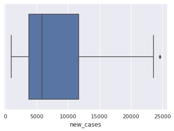

```python
sns.boxplot(x=df['new_cases'])
```

From the boxplot above, we can found that there is only little outliers (black points out of the box plot).

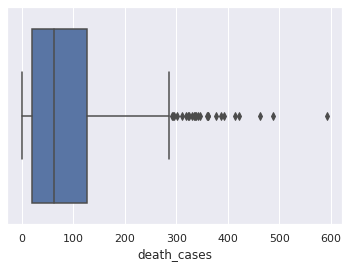

```python
sns.boxplot(x=df['death_cases'])
```

From the boxplot above, we can found that there are a few outliers (black points out of the box plot).

```python
df.describe()
```

|  | death_cases | new_cases | import_cases | recovered_cases | active_cases | unvax_cases | pvax_cases | fvax_cases | boostvax_cases | daily_vax | pfizer | sinovac | astra | sinopharm | tot_cansino | pending | rtk_ag | pcr |
| --- | --- | --- | --- | --- | --- | --- | --- | --- | --- | --- | --- | --- | --- | --- | --- | --- | --- | --- |
| count | 300.000000 | 300.000000 | 300.00000 | 300.000000 | 300.000000 | 300.000000 | 300.000000 | 300.000000 | 300.000000 | 300.000000 | 300.000000 | 300.000000 | 300.000000 | 300.000000 | 300.000000 | 300.000000 | 300.000000 | 300.000000 |
| mean | 100.180000 | 8111.050000 | 13.29000 | 7938.380000 | 95734.203333 | 4650.690000 | 1313.793333 | 2128.260000 | 18.306667 | 186831.866667 | 102540.296667 | 68061.456667 | 13609.460000 | 103.493333 | 652.166667 | 1864.993333 | 61654.496667 | 46332.683333 |
| std | 107.979843 | 6299.350336 | 10.30014 | 6303.910502 | 76647.724219 | 3559.815374 | 2088.560623 | 2381.112285 | 42.988207 | 163353.601520 | 81044.764432 | 92849.089577 | 13893.258547 | 177.964644 | 1439.957524 | 15631.014827 | 31933.890588 | 17808.972703 |
| min | 1.000000 | 941.000000 | 0.00000 | 1052.000000 | 14025.000000 | 653.000000 | 0.000000 | 0.000000 | 0.000000 | 65.000000 | 0.000000 | 2.000000 | 0.000000 | 0.000000 | 0.000000 | 0.000000 | 10966.000000 | 18708.000000 |
| 25% | 19.000000 | 3741.250000 | 6.00000 | 3328.250000 | 37161.500000 | 1479.000000 | 36.750000 | 23.750000 | 0.000000 | 40622.500000 | 29021.500000 | 4227.500000 | 254.250000 | 0.000000 | 0.000000 | 6.000000 | 32921.000000 | 31110.000000 |
| 50% | 63.000000 | 5820.000000 | 10.00000 | 5568.000000 | 67044.000000 | 3662.500000 | 155.500000 | 754.500000 | 0.000000 | 138358.500000 | 84123.500000 | 16103.000000 | 10557.500000 | 0.000000 | 0.500000 | 30.000000 | 58231.000000 | 42042.000000 |
| 75% | 126.750000 | 11685.750000 | 18.00000 | 11376.000000 | 136673.500000 | 7159.750000 | 1668.750000 | 3979.000000 | 0.000000 | 288605.250000 | 165419.250000 | 119012.750000 | 24379.250000 | 150.000000 | 454.500000 | 101.250000 | 84868.000000 | 59948.750000 |
| max | 592.000000 | 24599.000000 | 64.00000 | 24855.000000 | 263871.000000 | 12685.000000 | 7322.000000 | 8447.000000 | 178.000000 | 582088.000000 | 305017.000000 | 317163.000000 | 59254.000000 | 730.000000 | 7722.000000 | 156588.000000 | 149747.000000 | 90293.000000 |

```python
Q1 = df.quantile(0.25)
Q3 = df.quantile(0.75)
IQR = Q3 - Q1
print(IQR)
```

```
death_cases           107.75
new_cases            7944.50
import_cases           12.00
recovered_cases      8047.75
active_cases        99512.00
unvax_cases          5680.75
pvax_cases           1632.00
fvax_cases           3955.25
boostvax_cases          0.00
daily_vax          247982.75
pfizer             136397.75
sinovac            114785.25
astra               24125.00
sinopharm             150.00
tot_cansino           454.50
pending                95.25
rtk_ag              51947.00
pcr                 28838.75
dtype: float64
```

# Plot Different Features Against One Other

The cell below create new columns which are **year** and **month** in the dataframe **df**.

```python
df['year'] = pd.DatetimeIndex(df['date']).year
df['month'] = pd.DatetimeIndex(df['date']).month
```

### Bar Chart

Bar graphs are used to compare things between different groups or to track changes over time.In this case, the number of deaths caused by COVID-19, the number of active COVID-19 cases over months,comparison between COVID-19 tests and were visualize using bar chart.

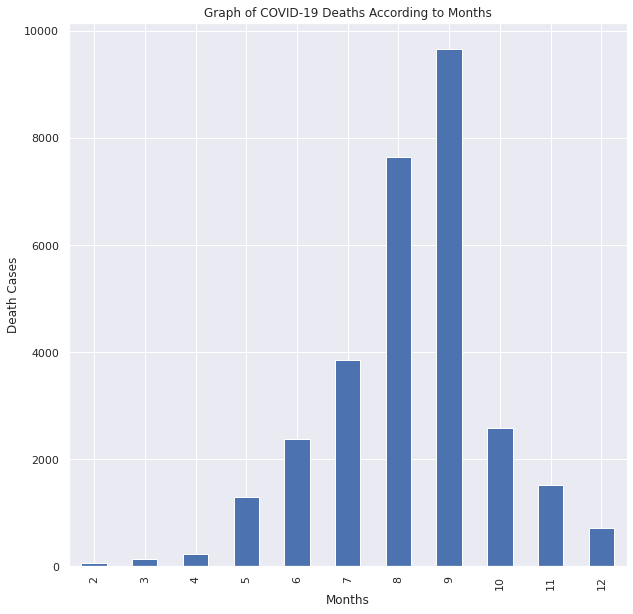

```python
fig = df.groupby('month').death_cases.sum().plot(kind='bar', title='Graph of COVID-19 Deaths According to Months', figsize=(10,10))
fig.set_ylabel("Death Cases")
fig.set_xlabel("Months")
```

Based on the graph of COVID-19 Deaths According to Months, we can found that the death cases caused by COVID-19 is highest in **September**, follow by **August**. Besides that, the death case in February is the least as there is only the last few days of the data were included.

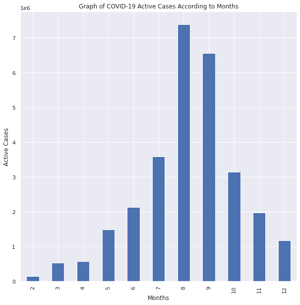

```python
fig = df.groupby('month').active_cases.sum().plot(kind='bar', title='Graph of COVID-19 Active Cases According to Months', figsize=(10,10))
fig.set_ylabel("Active Cases")
fig.set_xlabel("Months")
```

Based on the graph of Graph of COVID-19 Active Cases According to Months, we can found that in August, the COVID-19 Active Cases is highest, follow by the COVID-19 active cases in September. Besides that, the active case in February is the least as there is only the last few days of the data were included.

```
[]
```

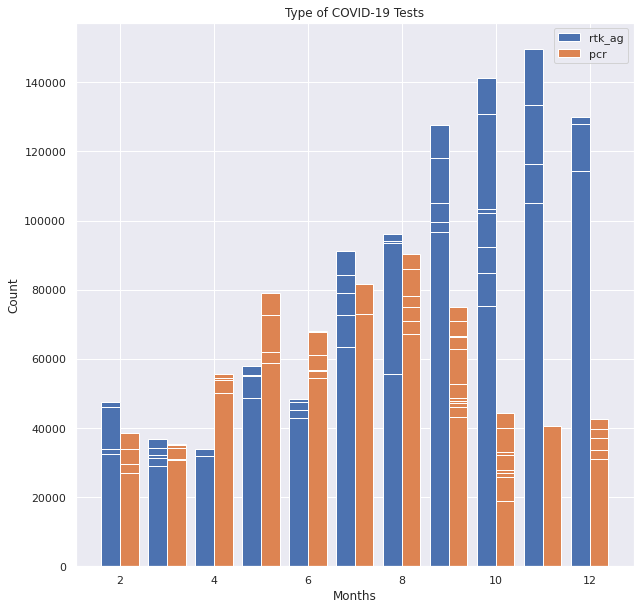

```python
df.groupby('month').sum()

fig = plt.figure(figsize=(10,10))

plt.title("Type of COVID-19 Tests")
plt.bar(df['month'] - 0.2,df['rtk_ag'],0.4,label ='rtk_ag')
plt.bar(df['month']+ 0.2 ,df['pcr'],0.4,label ='pcr')
plt.xlabel("Months")
plt.ylabel("Count")

plt.legend()
plt.plot()
```

Based on the the bar chart above, we can found that most of the people prefer rtk-ag test as their COVID-19 tests from **July** and onwards while most of the people prefer to use pcr test during **May** and **June**

```python
selected_columns = df[["month","pfizer","sinovac","astra","sinopharm","tot_cansino","pending"]]

df_vax_type = selected_columns.copy()

df_vax_type.head(5)
```

|  | month | pfizer | sinovac | astra | sinopharm | tot_cansino | pending |
| --- | --- | --- | --- | --- | --- | --- | --- |
| 0 | 2 | 62 | 2 | 0 | 0 | 0 | 1 |
| 1 | 2 | 1147 | 2 | 0 | 0 | 0 | 2 |
| 2 | 2 | 4058 | 2 | 1 | 0 | 0 | 7 |
| 3 | 2 | 6693 | 5 | 0 | 0 | 0 | 18 |
| 4 | 2 | 6709 | 4 | 0 | 0 | 0 | 4 |

```
[]
```

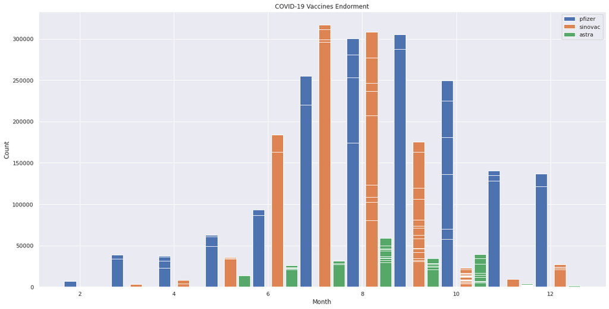

```python
df_vax_type.groupby('month').sum()

fig = plt.figure(figsize=(20,10))


plt.title("COVID-19 Vaccines Endorment")
plt.bar(df_vax_type['month'] - 0.2,df_vax_type['pfizer'],0.25,label ='pfizer')
plt.bar(df_vax_type['month']+ 0.2 ,df_vax_type['sinovac'],0.25,label ='sinovac')
plt.bar(df_vax_type['month']+ 0.5 ,df_vax_type['astra'],0.25,label ='astra')
plt.xlabel("Month")
plt.ylabel("Count")

plt.legend()
plt.plot()
```

### Line Graph

Line graph was commonly used to create a graphical depiction of changes in values over time. In this case, the COVID-19 cases and the comparison between death cases, recovered cases and active cases were represented using line graph.

Copy of data to new dataframe called df_cases

```python
# Group particular columns to df_cases.
selected_columns = df[["month","active_cases","new_cases","recovered_cases","death_cases"]]
df_cases = selected_columns.copy()

df_cases.head(5)
```

|  | month | active_cases | new_cases | recovered_cases | death_cases |
| --- | --- | --- | --- | --- | --- |
| 0 | 2 | 30572 | 3545 | 3331 | 12 |
| 1 | 2 | 28738 | 1924 | 3752 | 13 |
| 2 | 2 | 27903 | 2253 | 3085 | 10 |
| 3 | 2 | 26937 | 2364 | 3320 | 10 |
| 4 | 2 | 26118 | 2437 | 3251 | 9 |

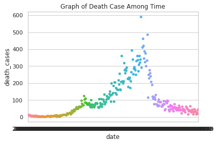

```python
# use to set style of background of plot
sns.set(style="whitegrid")

# plotting strip plot with seaborn
# deciding the attributes of dataset on
# which plot should be made
ax = sns.swarmplot(x='date', y='death_cases', data=df)

# giving title to the plot
plt.title('Graph of Death Case Among Time')

# function to show plot
plt.show()
```

Based on the Graph of death case among time, we can found that there is an increase in COVID-19 death cases from 100+ to 500+. After a few days, the death case due to COVID-19 Pandemic decreased back to less than 100 of cases everyday.

```
[]
```

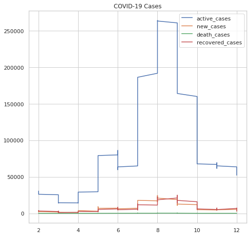

```python
df_cases.groupby('month').sum()

fig = plt.figure(figsize=(8,8))
plt.title("COVID-19 Cases")
plt.plot(df['month'],df['active_cases'],label ='active_cases')
plt.plot(df['month'],df['new_cases'],label ='new_cases')
plt.plot(df['month'],df['death_cases'],label ='death_cases')
plt.plot(df['month'],df['recovered_cases'],label ='recovered_cases')

plt.legend()
plt.plot()
```

Based on the line graph above, we can found that the active case is largest in terms of numbers, following by new cases and recovered case where both of them were overlapping. Besides that, the death case due to COVID-19 Pandemic is the least.

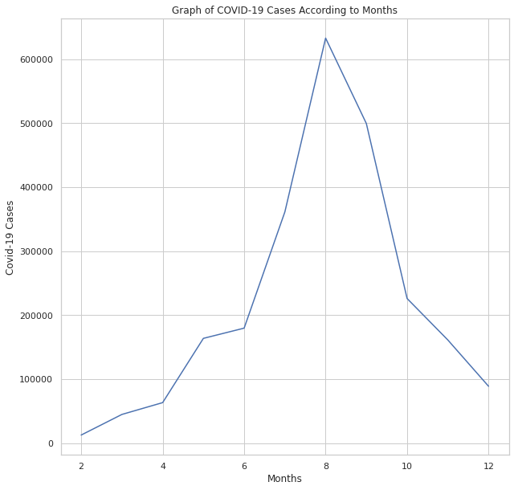

```python
fig = df.groupby('month').new_cases.sum().plot(title='Graph of COVID-19 Cases According to Months', figsize=(10,10))
fig.set_ylabel("Covid-19 Cases")
fig.set_xlabel("Months")
```

Based on the Graph of COVID-19 Cases According to Months, we can found that there is an increase of number of new COVID-19 cases from **February** and reached in the greatest number of cases in **August**. After that, the COVID-19 cases started to decrease back within 100000 in **Decembe**r.

### Area Graph

Area graphy was widely used to show the rise and fall of various data series over tim and conveying total amounts over time as well as some sub-categorical breakdowns (but only to a point.In this case, area graph was used to show the Covid-19 recovered case according to month and Covid-19 vaccination endorsement according to months.

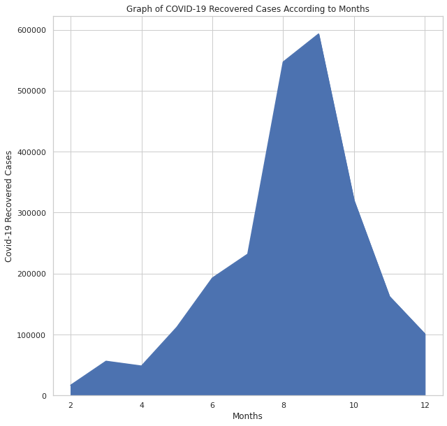

```python
fig = df.groupby('month').recovered_cases.sum().plot(kind='area', title='Graph of COVID-19 Recovered Cases According to Months', figsize=(10,10))
fig.set_ylabel("Covid-19 Recovered Cases")
fig.set_xlabel("Months")
```

Based on the are graph (Graph of COVID-19 Recovered Cases According to Months) above, we can found that there is an increase in COVID-19 recovered case from April to September, and then decrease back in December.

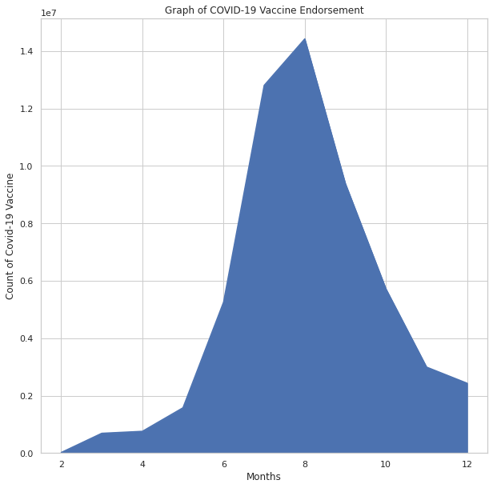

```python
fig = df.groupby('month').daily_vax.sum().plot(kind='area', title='Graph of COVID-19 Vaccine Endorsement', figsize=(10,10))
fig.set_ylabel("Count of Covid-19 Vaccine")
fig.set_xlabel("Months")
```

Based on the area graph (Graph of COVID-19 Vaccine Endorsement) above, we can found that there is an increase in daily COVID-19 Vaccine Endorsement from April to August, and then started to decrease back in December. This may be due to the reason that most of the people had taken their dose 1 and dose 2 vaccines.

# Machine Learning

### Linear Regresion

```python
from sklearn.linear_model import LinearRegression
from sklearn.model_selection import train_test_split
from sklearn.metrics import mean_squared_error, r2_score
df
```

|  | date | death_cases | new_cases | import_cases | recovered_cases | active_cases | unvax_cases | pvax_cases | fvax_cases | boostvax_cases | daily_vax | pfizer | sinovac | astra | sinopharm | tot_cansino | pending | rtk_ag | pcr | year | month |
| --- | --- | --- | --- | --- | --- | --- | --- | --- | --- | --- | --- | --- | --- | --- | --- | --- | --- | --- | --- | --- | --- |
| 0 | 2021-02-24 | 12 | 3545 | 1 | 3331 | 30572 | 3545 | 0 | 0 | 0 | 65 | 62 | 2 | 0 | 0 | 0 | 1 | 44841 | 30281 | 2021 | 2 |
| 1 | 2021-02-25 | 13 | 1924 | 6 | 3752 | 28738 | 1924 | 0 | 0 | 0 | 1151 | 1147 | 2 | 0 | 0 | 0 | 2 | 47439 | 38490 | 2021 | 2 |
| 2 | 2021-02-26 | 10 | 2253 | 7 | 3085 | 27903 | 2253 | 0 | 0 | 0 | 4068 | 4058 | 2 | 1 | 0 | 0 | 7 | 46207 | 34014 | 2021 | 2 |
| 3 | 2021-02-27 | 10 | 2364 | 1 | 3320 | 26937 | 2364 | 0 | 0 | 0 | 6716 | 6693 | 5 | 0 | 0 | 0 | 18 | 34017 | 29550 | 2021 | 2 |
| 4 | 2021-02-28 | 9 | 2437 | 1 | 3251 | 26118 | 2437 | 0 | 0 | 0 | 6717 | 6709 | 4 | 0 | 0 | 0 | 4 | 32557 | 26969 | 2021 | 2 |
| ... | ... | ... | ... | ... | ... | ... | ... | ... | ... | ... | ... | ... | ... | ... | ... | ... | ... | ... | ... | ... | ... |
| 295 | 2021-12-16 | 37 | 4262 | 36 | 4985 | 56156 | 955 | 29 | 3109 | 169 | 174433 | 18946 | 3813 | 325 | 268 | 150 | 150931 | 91581 | 33616 | 2021 | 12 |
| 296 | 2021-12-17 | 18 | 4362 | 28 | 5098 | 55380 | 969 | 47 | 3168 | 178 | 162223 | 9730 | 2690 | 144 | 253 | 138 | 149268 | 78413 | 31077 | 2021 | 12 |
| 297 | 2021-12-18 | 29 | 4083 | 34 | 5435 | 54000 | 1024 | 22 | 2893 | 144 | 72164 | 3672 | 1906 | 108 | 128 | 134 | 66216 | 62603 | 30918 | 2021 | 12 |
| 298 | 2021-12-19 | 19 | 3108 | 37 | 3701 | 53389 | 692 | 22 | 2251 | 143 | 79498 | 56218 | 10148 | 2095 | 84 | 209 | 10744 | 67749 | 24185 | 2021 | 12 |
| 299 | 2021-12-20 | 43 | 2589 | 46 | 3810 | 52161 | 653 | 21 | 1819 | 96 | 146136 | 121474 | 21211 | 1689 | 249 | 119 | 1394 | 114220 | 31012 | 2021 | 12 |

300 rows × 21 columns

The active cases is declared as x variable which is an independent variable while death_cases, which is number of daily death cases is declared as y variable, a target variable. The dataset is split into 80% of training set and 20% of testing set. Then, fit it to the model reg. Finally, the model is evaluated using mean squared error and r2 score. A 87% of r2 score indicates 87% of data fits the model, means the model's performance is not bad.

```python
x = df[['active_cases']]
y = df['death_cases']

X_train, X_test, y_train, y_test = train_test_split(x, y, test_size=0.2,
                                                    random_state=0)
# create linear regression object
reg = LinearRegression()

# train the model using the training sets
reg.fit(X_train, y_train)

y_predicted = reg.predict(X_test)

print("Mean squared error: %.2f" % mean_squared_error(y_test, y_predicted))
print('R²: %.2f' % r2_score(y_test, y_predicted))
```

```
Mean squared error: 1148.46
R²: 0.87
```

A scatter plot graph is plot to visualize the model performance.

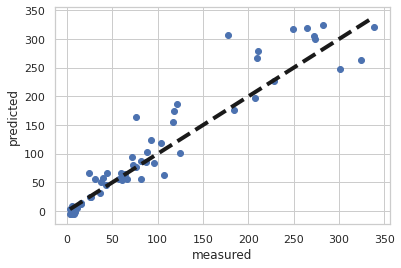

```python
fig, ax = plt.subplots()
ax.scatter(y_test, y_predicted)
ax.plot([y_test.min(), y_test.max()], [y_test.min(), y_test.max()], 'k--', lw=4)
ax.set_xlabel('measured')
ax.set_ylabel('predicted')
plt.show()
```

In order to find suitable independent variables to fit multiple linear regression model, a scatter plot of number of active cases against number of daily death cases are plotted to visualize their relationship.

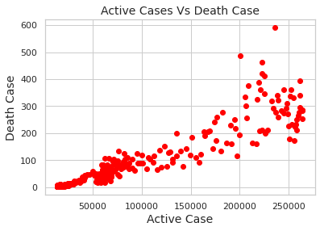

```python
plt.scatter(df['active_cases'], df['death_cases'], color='red')
plt.title('Active Cases Vs Death Case', fontsize=14)
plt.xlabel('Active Case', fontsize=14)
plt.ylabel('Death Case', fontsize=14)
plt.grid(True)
plt.show()
```

In order to find suitable independent variables to fit multiple linear regression model, a scatter plot of number of unvaccinated COVID-19 cases against number of daily death cases are plotted to visualize their relationship.

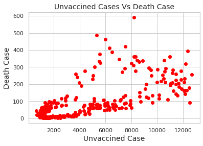

```python
plt.scatter(df['unvax_cases'], df['death_cases'], color='red')
plt.title('Unvaccined Cases Vs Death Case', fontsize=14)
plt.xlabel('Unvaccined Case', fontsize=14)
plt.ylabel('Death Case', fontsize=14)
plt.grid(True)
plt.show()
```

In order to find suitable independent variables to fit multiple linear regression model, a scatter plot of number of number of daily vaccinated taken against number of daily death cases are plotted to visualize their relationship.

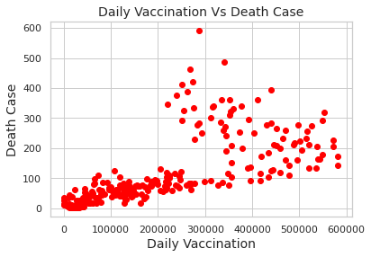

```python
plt.scatter(df['daily_vax'], df['death_cases'], color='red')
plt.title('Daily Vaccination Vs Death Case', fontsize=14)
plt.xlabel('Daily Vaccination', fontsize=14)
plt.ylabel('Death Case', fontsize=14)
plt.grid(True)
plt.show()
```

In order to find suitable independent variables to fit multiple linear regression model, a scatter plot of number of number of daily new COVID-19 cases against number of daily death cases are plotted to visualize their relationship.

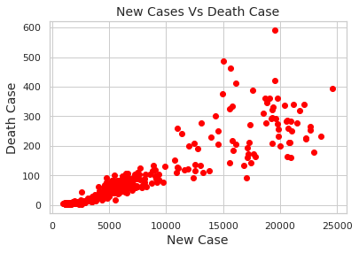

```python
plt.scatter(df['new_cases'], df['death_cases'], color='red')
plt.title('New Cases Vs Death Case', fontsize=14)
plt.xlabel('New Case', fontsize=14)
plt.ylabel('Death Case', fontsize=14)
plt.grid(True)
plt.show()
```

```python
X = df.iloc[:,np.r_[2,5]]
Y = df.iloc[:,1]

X_train, X_test, y_train, y_test = train_test_split(X, Y, test_size=0.2,
                                                    random_state=0)
# create linear regression object
reg = LinearRegression()

# train the model using the training sets
reg.fit(X_train, y_train)

y_predicted = reg.predict(X_test)

print("Mean squared error: %.2f" % mean_squared_error(y_test, y_predicted))
print('R²: %.2f' % r2_score(y_test, y_predicted))
```

```
Mean squared error: 1226.95
R²: 0.86
```

A scatter plot graph is plot to visualize the model performance.

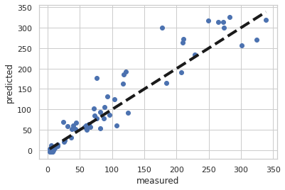

```python
fig, ax = plt.subplots()
ax.scatter(y_test, y_predicted)
ax.plot([y_test.min(), y_test.max()], [y_test.min(), y_test.max()], 'k--', lw=4)
ax.set_xlabel('measured')
ax.set_ylabel('predicted')
plt.show()
```

# Interactive Dashboard

In order to build interactive dashboard on Google Colab, plotly.express, display, HTML, interact, and widgets are imported. plotly.express library is used to plot the graph and chart while HTML is to display some numerical statistics. For interact imported from ipywidgets, it is used to perform interaction with the users. Then a data frame group by month is created for later use.

```python
import plotly.express as px
from IPython.core.display import display, HTML
from ipywidgets import interact
import ipywidgets as widgets
df_month = df.groupby(['month']).sum()
df_month['month'] = df_month.index
df_month.reset_index(drop=True, inplace=True)

sorted_month_df = df_month.sort_values('new_cases', ascending= False)
```

bubble_chart() function is created and used to plot a scatter plot graph of month against monthly new cases. The user is able to select highest new cases month ranged from 0 to 11 which implemented using widgets.IntSlider(). The user able to select to highest new cases month by using the slider.

```python
def bubble_chart(n):
  fig = px.scatter(sorted_month_df.head(n), x='month',y='new_cases', size='new_cases',
                  color='month', hover_name='month',size_max=60)

  fig.update_layout(
    title=str(n) +" Highest New Cases Month",
    xaxis_title="Month",
    yaxis_title="Monthly New Cases",
    width = 700
    )
  fig.show();

interact(bubble_chart, n=widgets.IntSlider(min=0, max=11, step=1, value=5));
ipywLayout.display='none'
```

A function named stats_of_month is created and used to display number of news cases per month, recovered cases per month, death cases per month and vaccination took per month. The function also plot a bar chart of every day of the selected month against death cases. The user is able to interact by typing in the number which represents the month in the text box.

```python
def stats_of_month(Month):
  n = int(Month)
  death_total = df_month.loc[df_month['month'] == n , 'death_cases'].sum()
  vac_total = int(df_month.loc[df_month['month'] == n , 'daily_vax'].sum())
  recovered_total = int(df_month.loc[df_month['month'] == n , 'recovered_cases'].sum())
  new_cases = int(df_month.loc[df_month['month'] == n , 'new_cases'].sum())

  display(HTML("<div style = 'background-color: #504e4e; padding: 30px '>" +
              "<span style='color: red; font-size:30px;margin-left:20px;'> New Cases: "  + str(new_cases) +"</span>" +
                "<span style='color: lightgreen; font-size:30px; margin-left:20px;'> Recovered Cases: " + str(recovered_total) + "</span>"+
             "<span style='color: red; font-size:30px;margin-left:20px;'> Death Cases: " + str(death_total) + "</span>"+
              "<span style='color: #fff; font-size:30px;'> Vaccination took: "  + str(vac_total) +"</span>" +
             "</div>")
       )
  df_case = df.loc[df['month']== n]
  return px.bar(
      df_case,
      x='date',
      y='death_cases',
      title= "Daily death case in month "+ str(n), # the axis names
      color_discrete_sequence=["blueviolet"],
      height=500,
      width=800
  )

interact(active_case_death_case, Month='8')
```

[output not shown]

A function named vaccination_type_bar_chart is created and used to display number of the selected vaccination type injected per month. The user can select the type of the vaccine in the drop down menu and number of selected vaccination type injected per month will be shown.

```python
from ipywidgets.widgets import widget
def vaccination_type_bar_chart(vaccination_type):
  fig = px.bar(df, x='month', y=vaccination_type ,
                  color='month', hover_name='month')

  fig.update_layout(
    title="Endorsement of "+ vaccination_type +" Vaccine based on Month",
    xaxis_title="Month",
    yaxis_title="Count",
    width = 700
    )
  fig.show();

interact(vaccination_type_bar_chart,vaccination_type=['sinovac','pfizer','astra','sinopharm','tot_cansino' ]);
ipywLayout = widgets.Layout(border='solid 2px blue')
ipywLayout.display='none'
```

```python
!pip install nbconvert
```